# stats 506 homework 2

Author

Chengrui Zhao

## problem1: dice game

Let’s play a dice game. It costs $2 to play. You roll a single 6-sided die.

On a roll of 3 or 5, you win twice your roll. On any other roll, you lose. The input and output should be:

Input: The number of dice to roll. Output: Total winnings

a, Version 1: Implement this game using a loop.

```r
#' Function to get the final amount of money after all games
#'
#' @param n a numeric vector, the number of games played
#' @return the amount of money after all games
play_dice<-function(n){
  prob<-sample(c(1:6),n,replace = T)
  mon<-0
  for (i in 1:length(prob)){
    if(prob[i]==3){
      mon<-mon+3*2-2
    }
    else if(prob[i]==5){
      mon<-mon+5*2-2
    }
    else{
      mon<-mon-2
    }
  }
  return(mon)
}
```

Here using for function as the loop, first get numbers with replacement, then use for to get the condition of amount of money for each game, every game we lose 2$, but when the dice rolls to 3 we win 3*2=6$ (so in this game we get 6-2=4), when the dice rolls to 5 we win 5*2=10$ (so in this game we get 10-2=8), then get the amount of money

Version 2: Implement this game using built-in R vectorized functions.

```r
#' Function to get the final amount of money after all games
#'
#' @param n a numeric vector, the number of games played
#' @return the amount of money after all games
play_dice<-function(n){
  prob<-sample(c(1:6),n,replace = T)
  mon<-0
  prob3<-sum(prob==3)
  prob5<-sum(prob==5)
  mon<-(3*2-2)*prob3+(5*2-2)*prob5-2*(n-prob3-prob5)
  return(mon)
}
```

Here the built-in R vectorized functions used is mainly sum by using it to get the number of games rolling to 3 and 5.

Version 3: Implement this by rolling all the dice into one and collapsing the die rolls into a single table(). (Hint: Be careful indexing the table - what happens if you make a table of a single dice roll? You may need to look to other resources for how to solve this.)

```r
#' Function to get the final amount of money after all games
#'
#' @param n a numeric vector, the number of games played
#' @return the amount of money after all games
play_dice<-function(n){
  prob<-sample(c(1:6),n,replace = T)
  table1<-table(prob)
  mon<-ifelse("3" %in% names(table1), (2 * 3) * table1[["3"]], 0)+ifelse("5" %in% names(table1), (2 * 5) * table1[["5"]], 0)-2*n
  return(mon)
}
```

Here the table is used to get the total number of from 1 to 6 in all games and then the amount of money is obtained. To solve the problem of reporting error due to no specific number, we can use ifelse, if the specific number exist, just take it, or else if it doesn’t exist, just give 0.

Version 4: Implement this game by using one of the “apply” functions.

```r
#' Function to get the final amount of money after all games
#'
#' @param n a numeric vector, the number of games played
#' @return the amount of money after all games
play_dice<-function(n){
  winning<-function(){
    prob<-sample(c(1:6),1)
    if(prob==3){
      return(3*2-2)
    }
    if(prob==5){
      return(5*2-2)
    }
    else{
      return(-2)
    }
  }
  sap<-sapply(1:n,winning())
  mon<-sum(sap)
  return(mon)
}
```

Here the “apply” function used is sapply, first build a function inside original function, which make rules about how much money to add for each game, then take it as function in sapply for each game, finally add all of them.

b, Demonstrate that all versions work. Do so by running each a few times, once with an input a 3, and once with an input of 3,000.

```r
#' Function to get the final amount of money after all games
#'
#' @param n a numeric vector, the number of games played
#' @return the amount of money after all games
play_dice<-function(n){
  prob<-sample(c(1:6),n,replace = T)
  mon<-0
  for (i in 1:length(prob)){
    if(prob[i]==3){
      mon<-mon+3*2-2
    }
    else if(prob[i]==5){
      mon<-mon+5*2-2
    }
    else{
      mon<-mon-2
    }
  }
  return(mon)
}

#use input 3 and 3000
play_dice(3)
```

```
[1] 14
```

```r
play_dice(3000)
```

```
[1] 2014
```

Here test for loop, it works as it shows number for 3 and 3000 games.

```r
#' Function to get the final amount of money after all games
#'
#' @param n a numeric vector, the number of games played
#' @return the amount of money after all games
play_dice<-function(n){
  prob<-sample(c(1:6),n,replace = T)
  mon<-0
  prob3<-sum(prob==3)
  prob5<-sum(prob==5)
  mon<-(3*2-2)*prob3+(5*2-2)*prob5-2*(n-prob3-prob5)
  return(mon)
}

#use input 3 and 3000
play_dice(3)
```

```
[1] -6
```

```r
play_dice(3000)
```

```
[1] 1786
```

Here test built-in R vectorized function, it works as it shows number for 3 and 3000 games.

```r
#' Function to get the final amount of money after all games
#'
#' @param n a numeric vector, the number of games played
#' @return the amount of money after all games
play_dice<-function(n){
  prob<-sample(c(1:6),n,replace = T)
  table1<-table(prob)
  mon<-ifelse("3" %in% names(table1), (2 * 3) * table1[["3"]], 0)+ifelse("5" %in% names(table1), (2 * 5) * table1[["5"]], 0)-2*n
  return(mon)
}

#use input 3 and 3000
play_dice(3)
```

```
[1] 4
```

```r
play_dice(3000)
```

```
[1] 1654
```

Here test table function, it works as it shows number for 3 and 3000 games.

```r
#' Function to get the final amount of money after all games
#'
#' @param n a numeric vector, the number of games played
#' @return the amount of money after all games
play_dice<-function(n){
  winning<-function(){
    prob<-sample(c(1:6),1)
    if(prob==3){
      return(3*2-2)
    }
    if(prob==5){
      return(5*2-2)
    }
    else{
      return(-2)
    }
  }
  sap<-sapply(1:n,function(x)winning())
  mon<-sum(sap)
  return(mon)
}

#use input 3 and 3000
play_dice(3)
```

```
[1] -6
```

```r
play_dice(3000)
```

```
[1] 1906
```

Here test “apply” function, it works as it shows number for 3 and 3000 games.

c, Demonstrate that the four versions give the same result. Test with inputs 3 and 3,000. (You will need to add a way to control the randomization.)

```r
#use set seed to make the random value fixed
set.seed(5)

#' Function to get the final amount of money after all games
#'
#' @param n a numeric vector, the number of games played
#' @return the amount of money after all games
play_dice<-function(n){
  prob<-sample(c(1:6),n,replace = T)
  mon<-0
  for (i in 1:length(prob)){
    if(prob[i]==3){
      mon<-mon+3*2-2
    }
    else if(prob[i]==5){
      mon<-mon+5*2-2
    }
    else{
      mon<-mon-2
    }
  }
  return(mon)
}

#use input 3 and 3000
play_dice(3)
```

```
[1] 0
```

```r
play_dice(3000)
```

```
[1] 2226
```

Here use for loop, use set seed to fix it and the output is the same as other methods.

```r
#use set seed to make random value fixed
set.seed(5)

#' Function to get the final amount of money after all games
#'
#' @param n a numeric vector, the number of games played
#' @return the amount of money after all games
play_dice<-function(n){
  prob<-sample(c(1:6),n,replace = T)
  mon<-0
  prob3<-sum(prob==3)
  prob5<-sum(prob==5)
  mon<-(3*2-2)*prob3+(5*2-2)*prob5-2*(n-prob3-prob5)
  return(mon)
}

#use input 3 and 3000
play_dice(3)
```

```
[1] 0
```

```r
play_dice(3000)
```

```
[1] 2226
```

Here use built-in R vectorized function, use set seed to fix it and the output is the same as other methods.

```r
#use set seed to make rabdome value fixed
set.seed(5)

#' Function to get the final amount of money after all games
#'
#' @param n a numeric vector, the number of games played
#' @return the amount of money after all games
play_dice<-function(n){
  prob<-sample(c(1:6),n,replace = T)
  table1<-table(prob)
  mon<-ifelse("3" %in% names(table1), (2 * 3) * table1[["3"]], 0)+ifelse("5" %in% names(table1), (2 * 5) * table1[["5"]], 0)-2*n
  return(mon)
}

#use input 3 and 3000
play_dice(3)
```

```
[1] 0
```

```r
play_dice(3000)
```

```
[1] 2226
```

Here use table function, use set seed to fix it and the output is the same as other methods.

```r
#use set seed to make random value fixed
set.seed(5)

#' Function to get the final amount of money after all games
#'
#' @param n a numeric vector, the number of games played
#' @return the amount of money after all games
play_dice<-function(n){
  winning<-function(){
    prob<-sample(c(1:6),1)
    if(prob==3){
      return(3*2-2)
    }
    if(prob==5){
      return(5*2-2)
    }
    else{
      return(-2)
    }
  }
  sap<-sapply(1:n,function(x)winning())
  mon<-sum(sap)
  return(mon)
}

#use input 3 and 3000
play_dice(3)
```

```
[1] 0
```

```r
play_dice(3000)
```

```
[1] 2226
```

Here use “apply” function, use set seed to fix it and the output is the same as other methods.

d, Use the microbenchmark package to clearly demonstrate the speed of the implementations. Compare performance with a low input (1,000) and a large input (100,000). Discuss the results

```r
#first, get the microbenchmark
library(microbenchmark)
#' Function to get the final amount of money after all games
#'
#' @param n a numeric vector, the number of games played
#' @return the amount of money after all games
play_dice<-function(n){
  prob<-sample(c(1:6),n,replace = T)
  mon<-0
  for (i in 1:length(prob)){
    if(prob[i]==3){
      mon<-mon+3*2-2
    }
    else if(prob[i]==5){
      mon<-mon+5*2-2
    }
    else{
      mon<-mon-2
    }
  }
  return(mon)
}

#use microbenchmark to record time it takes to calculate the amount of money for 1000 and 100000 games
microbenchmark(play_dice(1000))
```

```
Unit: microseconds
            expr  min   lq    mean median   uq    max neval
 play_dice(1000) 81.1 83.2 133.143  84.85 87.3 4400.1   100
```

```r
microbenchmark(play_dice(100000))
```

```
Unit: milliseconds
             expr    min      lq     mean  median      uq     max neval
 play_dice(1e+05) 7.7162 8.13405 8.816805 8.55675 9.34095 14.9813   100
```

```r
#' Function to get the final amount of money after all games
#'
#' @param n a numeric vector, the number of games played
#' @return the amount of money after all games
play_dice<-function(n){
  prob<-sample(c(1:6),n,replace = T)
  mon<-0
  prob3<-sum(prob==3)
  prob5<-sum(prob==5)
  mon<-(3*2-2)*prob3+(5*2-2)*prob5-2*(n-prob3-prob5)
  return(mon)
}

#use microbenchmark to record time it takes to calculate the amount of money for 1000 and 100000 games
microbenchmark(play_dice(1000))
```

```
Unit: microseconds
            expr  min   lq    mean median   uq    max neval
 play_dice(1000) 46.3 47.7 103.721   48.1 48.8 5227.8   100
```

```r
microbenchmark(play_dice(100000))
```

```
Unit: milliseconds
             expr    min      lq     mean  median      uq   max neval
 play_dice(1e+05) 4.5803 4.64675 5.145085 4.90705 5.49755 8.515   100
```

```r
#' Function to get the final amount of money after all games
#'
#' @param n a numeric vector, the number of games played
#' @return the amount of money after all games
play_dice<-function(n){
  prob<-sample(c(1:6),n,replace = T)
  table1<-table(prob)
  mon<-ifelse("3" %in% names(table1), (2 * 3) * table1[["3"]], 0)+ifelse("5" %in% names(table1), (2 * 5) * table1[["5"]], 0)-2*n
  return(mon)
}

#use microbenchmark to record time it takes to calculate the amount of money for 1000 and 100000 games
microbenchmark(play_dice(1000))
```

```
Unit: microseconds
            expr   min     lq    mean median    uq    max neval
 play_dice(1000) 109.3 111.35 172.177 113.05 137.5 4859.9   100
```

```r
microbenchmark(play_dice(100000))
```

```
Unit: milliseconds
             expr    min      lq     mean median      uq     max neval
 play_dice(1e+05) 6.5698 7.73525 9.652866 8.5578 9.40275 80.6093   100
```

```r
#' Function to get the final amount of money after all games
#'
#' @param n a numeric vector, the number of games played
#' @return the amount of money after all games
play_dice<-function(n){
  winning<-function(){
    prob<-sample(c(1:6),1)
    if(prob==3){
      return(3*2-2)
    }
    if(prob==5){
      return(5*2-2)
    }
    else{
      return(-2)
    }
  }
  sap<-sapply(1:n,function(x)winning())
  mon<-sum(sap)
  return(mon)
}

#use microbenchmark to record time it takes to calculate the amount of money for 1000 and 100000 games
microbenchmark(play_dice(1000))
```

```
Unit: milliseconds
            expr    min     lq     mean median      uq    max neval
 play_dice(1000) 3.7551 3.9651 4.601865 4.3354 4.75575 8.3829   100
```

```r
microbenchmark(play_dice(100000))
```

```
Unit: milliseconds
             expr      min       lq    mean   median       uq      max neval
 play_dice(1e+05) 430.4669 513.5109 550.819 555.8105 590.0089 718.6904   100
```

e, Do you think this is a fair game? Defend your decision with evidence based upon a Monte Carlo simulation.

```r
#' Function to get the final amount of money after all games
#'
#' @param n a numeric vector, the number of games played
#' @return the amount of money after all games
play_dice<-function(n){
  prob<-sample(c(1:6),n,replace = T)
  mon<-0
  prob3<-sum(prob==3)
  prob5<-sum(prob==5)
  mon<-(3*2-2)*prob3+(5*2-2)*prob5-2*(n-prob3-prob5)
  return(mon)
}

#use Monte Carlo simulation to create 100 random numbers
mc<-round(runif(100,3,3000))

#generate the amount of money after these random number of games
dice<-c()
for(i in 1:length(mc)){
  dice<-c(dice, play_dice(mc[i]))
}

#get the mean number of games, if it's near zero then it's a fair game
mean(dice)
```

```
[1] 892.32
```

Here I choose to use built-in R vectorized function as it takes the least time to get output. The principle here is first generate several random numbers as the number of games, then use each of them in function to get the amount of money won in each game, combine them together and get the sum of it, if the mean is close to 0, it’s a fair game. However it’s not.

## problem2: linear regression

Download the cars data set available at https://corgis-edu.github.io/corgis/csv/cars/. The goal is to examine the relationship between torque and highway gas mileage.

a, The names of the variables in this data are way too long. Rename the columns of the data to more reasonable lengths.

```r
#read in the file
car<-read.csv("C:\\Users\\DELL\\Downloads\\cars.csv")

#change the name of the file
colnames(car)<-c("height","length","width","driveline","engine type","hybrid or not","forward gear number","transmission","city mpg","fuel type","highway mpg","classification","ID","make","model year","year","horsepower","torque")
```

b, Restrict the data to cars whose Fuel Type is “Gasoline”.

```r
#get cars with gasoline
car<-car[which(car$`fuel type`=="Gasoline"),]
```

Here restrict cars to those using gasoline.

c, Examine the distribution of highway gas mileage. Consider whether a transformation could be used. If so, generate the transformed variable and use this variable going forward. If not, provide a short justification.

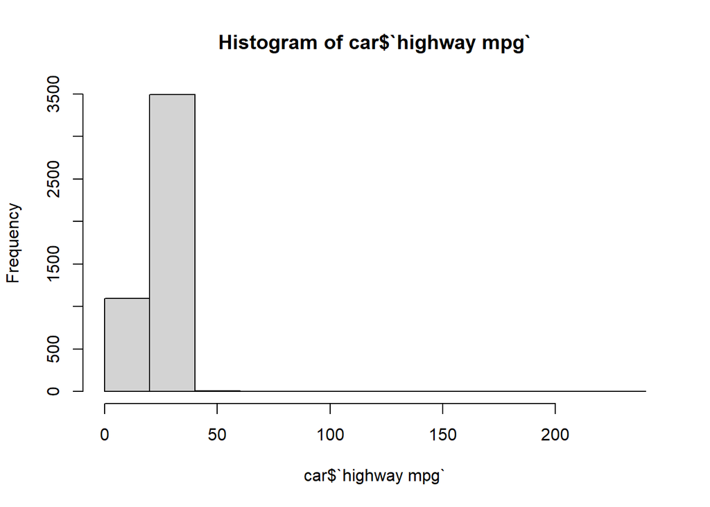

```r
#draw the histogram of mpg
hist(car$`highway mpg`)
```

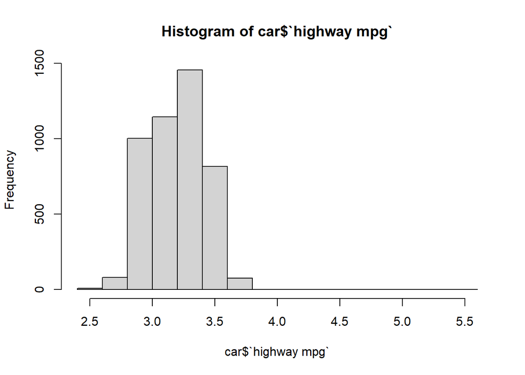

```r
#it seems that there exist high skew in mpg, use log transformation to adjust it
car$`highway mpg`<-log(car$`highway mpg`)
hist(car$`highway mpg`)
```

d, Fit a linear regression model predicting MPG on the highway. The predictor of interest is torque. Control for:

The horsepower of the engine

All three dimensions of the car

The year the car was released, as a categorical variable.

Briefly discuss the estimated relationship between torque and highway MPG. Be precise about the interpretation of the estimated coefficient.

```r
#convert year as factor
car$year<-as.factor(car$year)

#conduct regression
fit<-lm(car$`highway mpg`~car$torque+car$horsepower+car$height+car$length+car$width+car$year)

#get the summary of regression
summary(fit)
```

```
Call:
lm(formula = car$`highway mpg` ~ car$torque + car$horsepower +
    car$height + car$length + car$width + car$year)

Residuals:
     Min       1Q   Median       3Q      Max
-0.54759 -0.09385 -0.00414  0.09894  2.41852

Coefficients:
                 Estimate Std. Error t value Pr(>|t|)
(Intercept)     3.507e+00  2.216e-02 158.236  < 2e-16 ***
car$torque     -2.294e-03  6.757e-05 -33.956  < 2e-16 ***
car$horsepower  9.238e-04  6.984e-05  13.227  < 2e-16 ***
car$height      4.050e-04  3.456e-05  11.719  < 2e-16 ***
car$length      3.475e-05  2.710e-05   1.282  0.19980
car$width      -8.722e-05  2.774e-05  -3.144  0.00168 **
car$year2010   -2.181e-02  2.076e-02  -1.051  0.29342
car$year2011   -2.430e-03  2.072e-02  -0.117  0.90665
car$year2012    4.012e-02  2.089e-02   1.921  0.05485 .
---
Signif. codes:  0 '***' 0.001 '**' 0.01 '*' 0.05 '.' 0.1 ' ' 1

Residual standard error: 0.1412 on 4582 degrees of freedom
Multiple R-squared:  0.5638,    Adjusted R-squared:  0.563
F-statistic: 740.3 on 8 and 4582 DF,  p-value: < 2.2e-16
```

e, It seems reasonable that there may be an interaction between torque and horsepower. Refit the model (with lm) and generate an interaction plot, showing how the relationship between torque and MPG changes as horsepower changes. Choose reasonable values of torque, and show lines for three different reasonable values of horsepower.

```r
#first, get the interactions package
library("interactions")

#reconduct the regression into what the question says
fit1<-lm(`highway mpg`~torque*horsepower+height+length+width+year,data=car)

#get the summary of regression
summary(fit1)
```

```
Call:
lm(formula = `highway mpg` ~ torque * horsepower + height + length +
    width + year, data = car)

Residuals:
     Min       1Q   Median       3Q      Max
-0.55760 -0.08378 -0.00157  0.08194  2.45015

Coefficients:
                    Estimate Std. Error t value Pr(>|t|)
(Intercept)        3.854e+00  2.384e-02 161.669  < 2e-16 ***
torque            -3.533e-03  7.615e-05 -46.390  < 2e-16 ***
horsepower        -2.339e-04  7.632e-05  -3.064  0.00219 **
height             2.876e-04  3.215e-05   8.946  < 2e-16 ***
length             3.643e-05  2.500e-05   1.457  0.14525
width             -1.165e-04  2.561e-05  -4.548 5.55e-06 ***
year2010          -2.563e-02  1.915e-02  -1.338  0.18095
year2011          -5.886e-03  1.912e-02  -0.308  0.75822
year2012           3.640e-02  1.927e-02   1.889  0.05896 .
torque:horsepower  3.939e-06  1.391e-07  28.314  < 2e-16 ***
---
Signif. codes:  0 '***' 0.001 '**' 0.01 '*' 0.05 '.' 0.1 ' ' 1

Residual standard error: 0.1302 on 4581 degrees of freedom
Multiple R-squared:  0.6288,    Adjusted R-squared:  0.628
F-statistic: 862.1 on 9 and 4581 DF,  p-value: < 2.2e-16
```

```r
#get the number of data each year, choose the year with most data to continue
table(car$year)
```

```
2009 2010 2011 2012
  48 1633 1794 1116
```

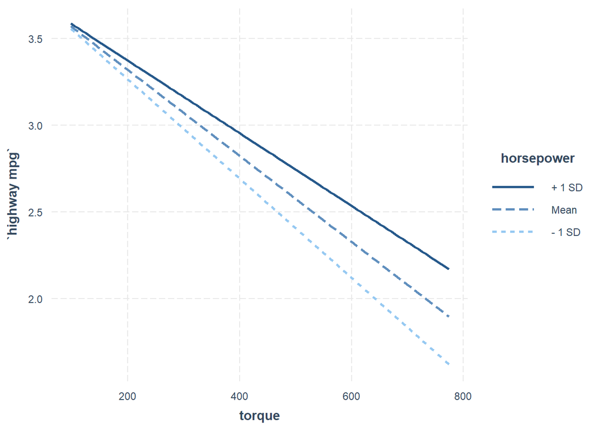

```r
#draw the interaction plot with all horsepower
interact_plot(fit1,"torque","horsepower",at=list(year=factor(2011),levels(car$year)))
```

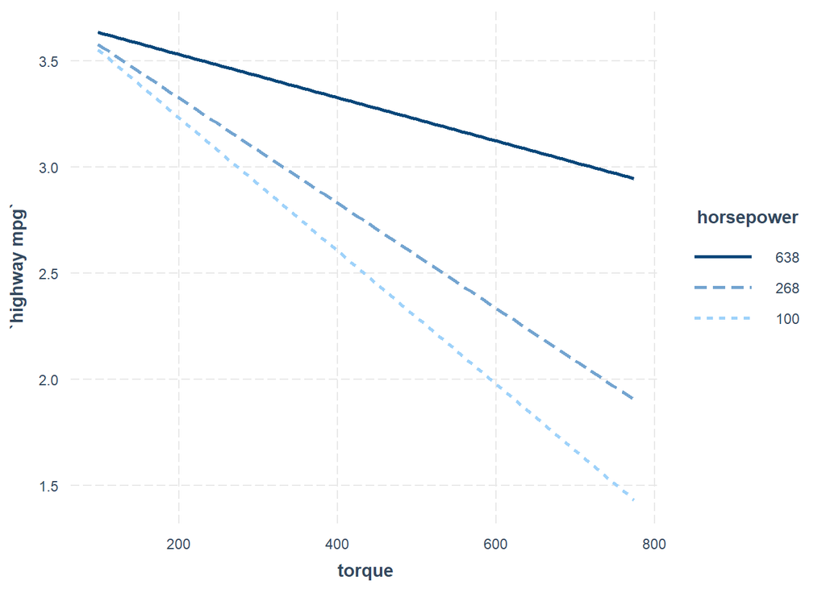

```r
#three horsepower are chosen by using the least, biggest and median number
car1=car[which(car$year==2011),ncol(car)-1]
m1=min(car1)
m2=max(car1)
m3=median(car1)

#draw the interaction plot with three chosen horsepower
interact_plot(fit1,"torque","horsepower",c(m1,m3,m2))
```

```r
#since \(\hat{\beta}\)=\((X^TX)^{-1}X^TY\), first get X, which is combination of all predictors and control
X<-cbind(1,car$torque,car$horsepower,car$height,car$length,car$width,car$year)

#get Y
Y<-car$`highway mpg`

#conduct \(\hat{\beta}\)=\((X^TX)^{-1}X^TY\) and get \(\hat{\beta}\)
beta<-solve(t(X)%*%X)%*%t(X)%*%Y
beta
```

```
              [,1]
[1,]  3.429214e+00
[2,] -2.305897e-03
[3,]  9.328547e-04
[4,]  4.019629e-04
[5,]  2.989852e-05
[6,] -9.177856e-05
[7,]  2.829937e-02
```